An extremely common task for remote sensing researchers is to connect remote sensing data with data on the ground. This might be a research question in itself - what reflectance wavelengths are most closely correlated with a particular ground feature? - or a ground-truthing for extrapolation and prediction, or development or testing of a model.

This tutorial explores the relationship between a Lidar-derived canopy height model and tree heights measured from the ground, because these two datasets provide a straightforward introduction to thinking about how to relate different sources of data. They are a good exemplar for the two major components of connecting airborne and ground data:

1. The mechanics: Finding the remotely sensed pixels that correspond to a given ground measurement
2. The science: Considering biases in each data source, and the ways the measurements might differ even if neither is incorrect

We will explore these issues between these two datasets, and you can use what you learn here as a roadmap for making similar comparisons between different datasets.

The two NEON data products that estimate tree height:

- **DP3.30015.001, Ecosystem structure**, aka Canopy Height Model (CHM)
- **DP1.10098.001, Vegetation structure**

The [CHM data](https://data.neonscience.org/data-products/DP3.30015.001) are derived from the Lidar point cloud data collected by the remote sensing platform. The [vegetation structure data](https://data.neonscience.org/data-products/DP1.10098.001) are collected by by field staff on the ground.

We will be using data from the Wind River Experimental Forest (WREF) NEON field site located in Washington state. The predominant vegetation there is tall evergreen conifers.

## Things You’ll Need To Complete This Tutorial

You will need the a recent version of R (4+) or Python (3.9+) loaded on your computer to complete this tutorial.

## 1. Setup

Start by installing and loading packages (if necessary) and setting options. Installation can be run once, then periodically to get package updates.

### R

One of the packages we’ll be using, `geoNEON`, is only available via GitHub, so it’s installed using the `devtools` package. The other packages can be installed directly from CRAN.

```r
install.packages("neonUtilities")
install.packages("neonOS")
install.packages("terra")
install.packages("devtools")
devtools::install_github("NEONScience/NEON-geolocation/geoNEON")
```

Now load packages. This needs to be done every time you run code. We’ll also set a working directory for data downloads (adapt the working directory path for your system).

```r
library(terra)
library(neonUtilities)
library(neonOS)
library(geoNEON)

options(stringsAsFactors=F)

wd <- "~/data"
```

### Python

There are a variety of spatial packages available in Python; we’ll use `rasterio` and `rioxarray`. We’ll also use several modules that are installed automatically with standard Python installations.

```python
pip install neonutilities
pip install geopandas
pip install rasterio
pip install rioxarray
pip install rasterstats
```

Now load packages.

```python
import neonutilities as nu
import pandas as pd
import numpy as np
import rasterstats as rs
import geopandas as gpd
import rioxarray as rxr
import matplotlib.pyplot as plt
import matplotlib.collections
import rasterio
from rasterio import sample
from rasterio.enums import Resampling
import requests
import time
import os
```

## 2. Vegetation structure data

In this section we’ll download the vegetation structure data, find the locations of the mapped trees, and join to the species and size data.

### R

Refer to the [cheat sheet](https://www.neonscience.org/sites/default/files/cheat-sheet-neonUtilities.pdf) for the `neonUtilities` package for more details and the complete index of possible function inputs.

```r
veglist <- loadByProduct(dpID="DP1.10098.001",
                         site="WREF",
                         package="basic",
                         release="RELEASE-2024",
                         check.size = FALSE)
```

### Python

Refer to the [cheat sheet](https://www.neonscience.org/sites/default/files/cheat-sheet-neonUtilities.pdf) for the `neonUtilities` package for more details and the complete index of possible function inputs. The cheat sheet is focused on the R package, but nearly all the inputs are the same.

```python
veglist = nu.load_by_product(dpid="DP1.10098.001",
                         site="WREF",
                         package="basic",
                         release="RELEASE-2024",
                         check_size = False)
```

### Get tree locations

#### R

Use the `getLocTOS()` function in the `geoNEON` package to get precise locations for the tagged plants. Refer to the package documentation for more details.

```r
vegmap <- getLocTOS(veglist$vst_mappingandtagging,
                          "vst_mappingandtagging")
```

```
## Please note locations will be calculated only for mapped woody individuals. To find subplot locations for unmapped individuals, use this function with the vst_apparentindividual, vst_non-woody, and/or vst_shrubgroup tables.
```

```
##
## Rate limit reached. Pausing for 100 seconds to reset.
```

#### Python

NEON doesn’t currently offer a Python equivalent to the `geoNEON` R package, so we’ll calculate the tree locations step-by-step. The trees are mapped as distance and azimuth from a reference location. The reference location data are accessible on the NEON API. The steps in this calculation are described in the [Data Product User Guide](https://data.neonscience.org/api/v0/documents/NEON_vegStructure_userGuide_vE.1).

First, get the names of the reference locations, and query the NEON API to retrieve their location data:

```python
vegmapall = veglist["vst_mappingandtagging"]
vegmap = vegmapall.loc[vegmapall["pointID"] != ""]
vegmap = vegmap.reindex()
vegmap["points"] = vegmap["namedLocation"] + "." + vegmap["pointID"]
veg_points = list(set(list(vegmap["points"])))

easting = []
northing = []
coord_uncertainty = []
elev_uncertainty = []
drop_points = []
```

```python
for i in veg_points:
    time.sleep(1)
    vres = requests.get("https://data.neonscience.org/api/v0/locations/"+i)
    vres_json = vres.json()
    if vres_json["data"] is not None:
        easting.append(vres_json["data"]["locationUtmEasting"])
        northing.append(vres_json["data"]["locationUtmNorthing"])
        props = pd.DataFrame.from_dict(vres_json["data"]["locationProperties"])
        cu = props.loc[props["locationPropertyName"] == "Value for Coordinate uncertainty"]["locationPropertyValue"]
        coord_uncertainty.append(cu[cu.index[0]])
        eu = props.loc[props["locationPropertyName"] == "Value for Elevation uncertainty"]["locationPropertyValue"]
        elev_uncertainty.append(eu[eu.index[0]])
    else:
        drop_points.append(i)

veg_points_clean = [v for v in veg_points if v not in drop_points]
```

```python
ptdct = dict(points=veg_points_clean,
             easting=easting,
             northing=northing,
             coordinateUncertainty=coord_uncertainty,
             elevationUncertainty=elev_uncertainty)
ptfrm = pd.DataFrame.from_dict(ptdct)
ptfrm.set_index("points", inplace=True)

vegmap = vegmap.join(ptfrm,
                     on="points",
                     how="inner")
```

Next, use the distance and azimuth data to calculate the precise locations of individuals, relative to the reference locations.

```python
vegmap["adjEasting"] = (vegmap["easting"]
                        + vegmap["stemDistance"]
                        * np.sin(vegmap["stemAzimuth"]
                                   * np.pi / 180))

vegmap["adjNorthing"] = (vegmap["northing"]
                        + vegmap["stemDistance"]
                        * np.cos(vegmap["stemAzimuth"]
                                   * np.pi / 180))
```

Add to the uncertainty estimate to account for error in measurement from the reference location, as described in the User Guide.

```python
vegmap["adjCoordinateUncertainty"] = vegmap["coordinateUncertainty"] + 0.6
vegmap["adjElevationUncertainty"] = vegmap["elevationUncertainty"] + 1
```

### Combine location with tree traits

Now we have the mapped locations of individuals in the `vst_mappingandtagging` table, and the annual measurements of tree dimensions such as height and diameter in the `vst_apparentindividual` table. To bring these measurements together, join the two tables, using the `joinTableNEON()` function from the `neonOS` package. Refer to the [Quick Start Guide](https://data.neonscience.org/data-products/DP1.10098.001) for Vegetation structure for more information about the data tables and the joining instructions `joinTableNEON()` is using.

#### R

```r
veg <- joinTableNEON(veglist$vst_apparentindividual,
                     vegmap,
                     name1="vst_apparentindividual",
                     name2="vst_mappingandtagging")
```

#### Python

Like the `geoNEON` package, there is not currently a Python equivalent to the `neonOS` package. Refer to the [Quick Start Guide](https://data.neonscience.org/data-products/DP1.10098.001) for Vegetation structure to find the data field to use to join the two tables.

```python
veglist["vst_apparentindividual"].set_index("individualID", inplace=True)
veg = vegmap.join(veglist["vst_apparentindividual"],
                  on="individualID",
                  how="inner",
                  lsuffix="_MAT",
                  rsuffix="_AI")
```

### Make a stem map

Let’s see what the data look like! Make a stem map, where each tree is mapped by a circle matching its size. This won’t look informative at the scale of the entire site, so we’ll subset to a single plot, WREF_075.

In addition to looking at only one plot, we’ll also target a single year. We want to match height measurements from the ground to remote sensing flights, so we need to pick a year when WREF was flown. We’ll use 2017. Use the `eventID` field from  
`vst_apparentindividual` to find the 2017 measurements. We use the `eventID` rather than the `date` because sampling bouts for vegetation structure are carried out in the winter, to avoid the growing season, and can sometimes extend into the following calendar year.

Note that in both languages the input to the function that draws a circle is a radius, but `stemDiameter` is just that, a diameter, so we will need to divide by two. And `stemDiameter` is in centimeters, but the mapping scale is in meters, so we also need to divide by 100 to get the scale right.

#### R

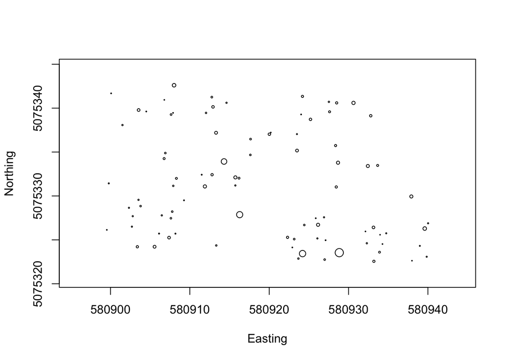

```r
veg2017 <- veg[which(veg$eventID.y=="vst_WREF_2017"),]

symbols(veg2017$adjEasting[which(veg2017$plotID=="WREF_075")],
        veg2017$adjNorthing[which(veg2017$plotID=="WREF_075")],
        circles=veg2017$stemDiameter[which(veg2017$plotID=="WREF_075")]/100/2,
        inches=F, xlab="Easting", ylab="Northing")
```

And now overlay the estimated uncertainty in the location of each stem, in blue:

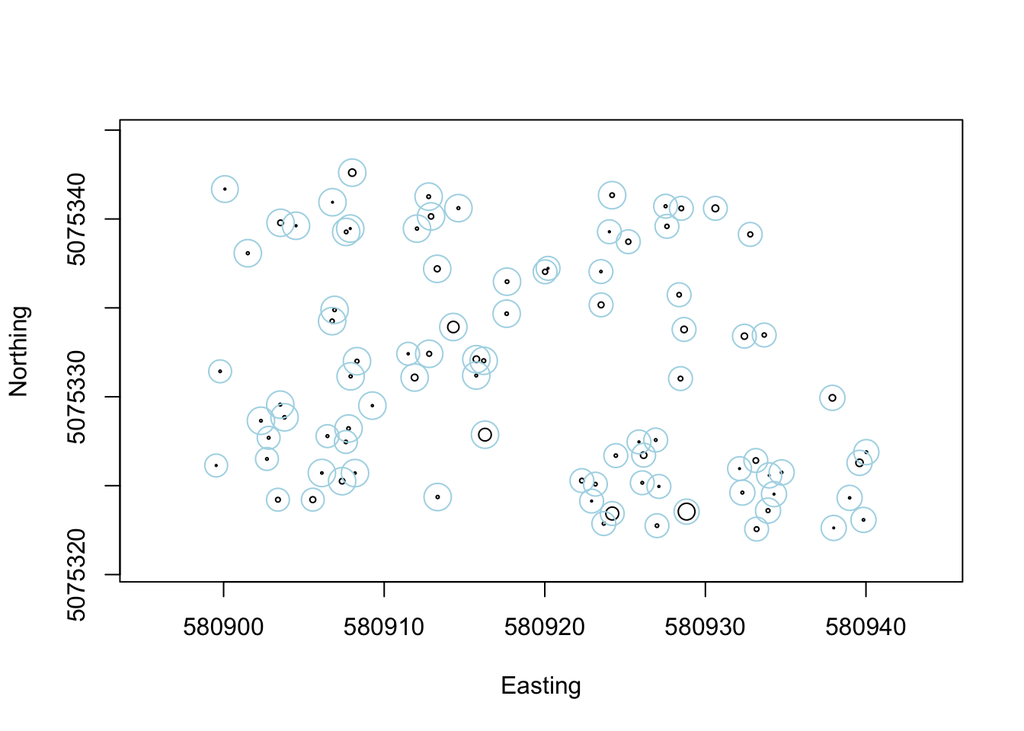

```r
symbols(veg2017$adjEasting[which(veg2017$plotID=="WREF_075")],
        veg2017$adjNorthing[which(veg2017$plotID=="WREF_075")],
        circles=veg2017$stemDiameter[which(veg2017$plotID=="WREF_075")]/100/2,
        inches=F, xlab="Easting", ylab="Northing")
symbols(veg2017$adjEasting[which(veg2017$plotID=="WREF_075")],
        veg2017$adjNorthing[which(veg2017$plotID=="WREF_075")],
        circles=veg2017$adjCoordinateUncertainty[which(veg2017$plotID=="WREF_075")],
        inches=F, add=T, fg="lightblue")
```

#### Python

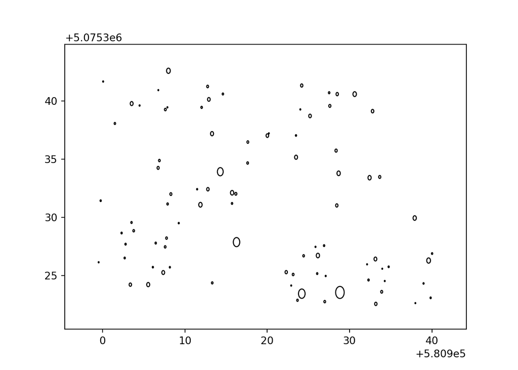

```python
veg2017 = veg.loc[veg["eventID_AI"]=="vst_WREF_2017"]
veg75 = veg2017.loc[veg2017["plotID_AI"]=="WREF_075"]

fig, ax = plt.subplots()

xy = np.array(tuple(zip(veg75.adjEasting, veg75.adjNorthing)))
srad = veg75.stemDiameter/100/2
patches = [plt.Circle(center, size) for center, size in zip(xy, srad)]

coll = matplotlib.collections.PatchCollection(patches, facecolors="white", edgecolors="black")
ax.add_collection(coll)

ax.margins(0.1)
plt.show()
```

And now overlay the estimated uncertainty in the location of each stem, in blue:

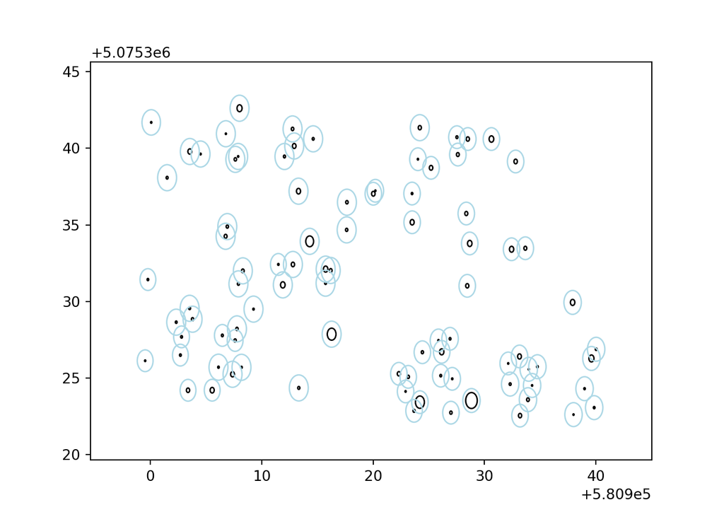

```python
fig, ax = plt.subplots()

sunc = veg75.adjCoordinateUncertainty
patchunc = [plt.Circle(center, size) for center, size in zip(xy, sunc)]

coll = matplotlib.collections.PatchCollection(patches, facecolors="None", edgecolors="black")
collunc = matplotlib.collections.PatchCollection(patchunc, facecolors="None", edgecolors="lightblue")
ax.add_collection(coll)
ax.add_collection(collunc)

ax.margins(0.1)
plt.show()
```

## 3. Canopy height model data

Now we’ll download the CHM tile covering plot WREF_075. Several other plots are also covered by this tile. We could download all tiles that contain vegetation structure plots, but in this exercise we’re sticking to one tile to limit download size and processing time.

The download will include several metadata files as well as the data tile. Load the data tile into the environment using the `terra` package in R and the `rasterio` and `rioxarray`` packages in Python.

### R

```r
byTileAOP(dpID="DP3.30015.001", site="WREF", year=2017,
          easting=veg2017$adjEasting[which(veg2017$plotID=="WREF_075")],
          northing=veg2017$adjNorthing[which(veg2017$plotID=="WREF_075")],
          check.size=FALSE, savepath=wd)

chm <- rast(paste0(wd, "/DP3.30015.001/neon-aop-products/2017/FullSite/D16/2017_WREF_1/L3/DiscreteLidar/CanopyHeightModelGtif/NEON_D16_WREF_DP3_580000_5075000_CHM.tif"))
```

Let’s view the tile.

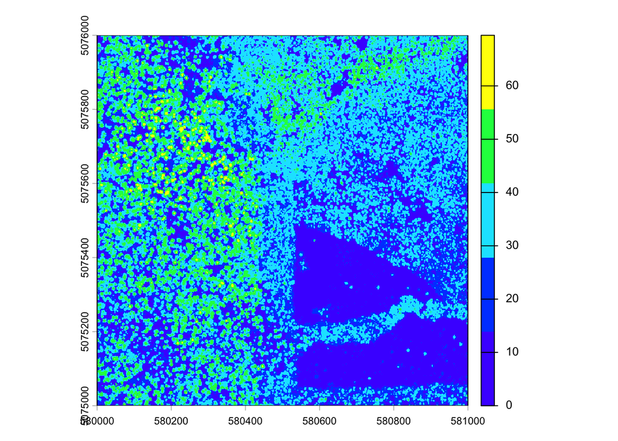

```r
plot(chm, col=topo.colors(5))
```

### Python

```python
nu.by_tile_aop(dpid="DP3.30015.001", site="WREF", year="2017",
          easting=list(veg75.adjEasting),
          northing=list(veg75.adjNorthing),
          check_size=False, savepath=os.getcwd())
```

We’ll read in versions of the tile in both `rasterio` and `rioxarray` to enable the different data extractions we’ll need to do later in the tutorial.

```python
chm = rasterio.open(os.getcwd() + "/DP3.30015.001/neon-aop-products/2017/FullSite/D16/2017_WREF_1/L3/DiscreteLidar/CanopyHeightModelGtif/NEON_D16_WREF_DP3_580000_5075000_CHM.tif")

chmx = rxr.open_rasterio(os.getcwd() + "/DP3.30015.001/neon-aop-products/2017/FullSite/D16/2017_WREF_1/L3/DiscreteLidar/CanopyHeightModelGtif/NEON_D16_WREF_DP3_580000_5075000_CHM.tif").squeeze()
```

Let’s view the tile.

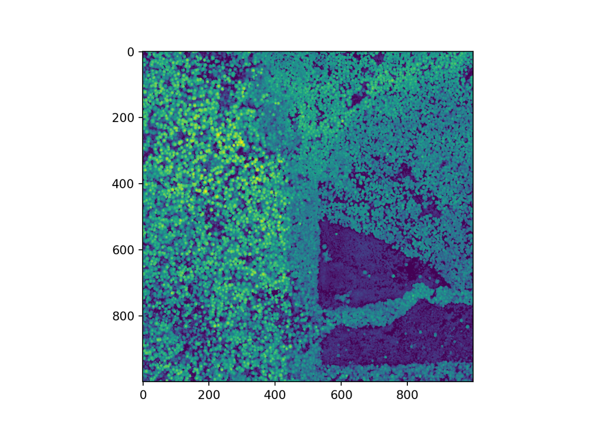

```python
plt.imshow(chm.read(1))
plt.show()
```

## 4. Comparing the two datasets

Now we have the heights of individual trees measured from the ground, and the height of the top surface of the canopy, measured from the air. There are many different ways to make a comparison between these two datasets! This section will walk through three different approaches.

### Subset the data

First, subset the vegetation structure data to only the trees that fall within this tile. This step isn’t strictly necessary, but it will make the processing faster.

Note that although we downloaded this tile by targeting plot WREF_075, there are other plots in the area covered by this tile - from here forward, we’re working with all measured trees within the tile area.

#### R

```r
vegsub <- veg2017[which(veg2017$adjEasting >= ext(chm)[1] &
                        veg2017$adjEasting <= ext(chm)[2] &
                        veg2017$adjNorthing >= ext(chm)[3] &
                        veg2017$adjNorthing <= ext(chm)[4]),]
```

#### Python

```python
vegsub = veg2017.loc[(veg2017["adjEasting"] >= chm.bounds[0]) &
                 (veg2017["adjEasting"] <= chm.bounds[1]) &
                 (veg2017["adjNorthing"] >= chm.bounds[2]) &
                 (veg2017["adjNorthing"] <= chm.bounds[3])]
vegsub = vegsub.reset_index(drop=True)
```

### Canopy height at mapped tree locations

Starting with a very simple first pass: get the CHM value matching the coordinates of each mapped plant. Then make a scatter plot of each tree’s height vs. the CHM value at its location.

#### R

The `extract()` function from the `terra` package gets the values from the tile at the given coordinates.

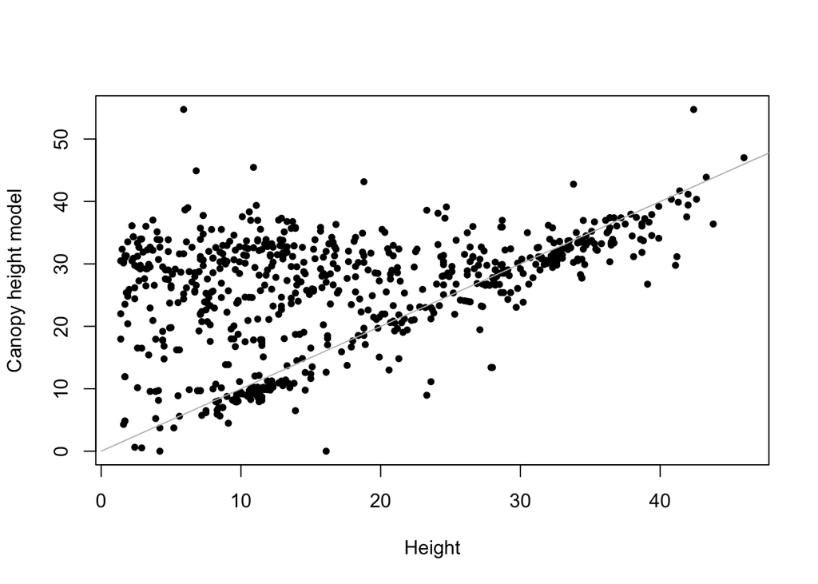

```r
valCHM <- extract(chm,
                  cbind(vegsub$adjEasting,
                  vegsub$adjNorthing))

plot(valCHM$NEON_D16_WREF_DP3_580000_5075000_CHM~
       vegsub$height, pch=20, xlab="Height",
     ylab="Canopy height model")
lines(c(0,50), c(0,50), col="grey")
```

How strong is the correlation between the ground and lidar measurements?

```r
cor(valCHM$NEON_D16_WREF_DP3_580000_5075000_CHM,
    vegsub$height, use="complete")
```

```
## [1] 0.3910897
```

#### Python

The `sample_gen()` function from the `rasterio.sample` module gets the values from the tile at the given coordinates.

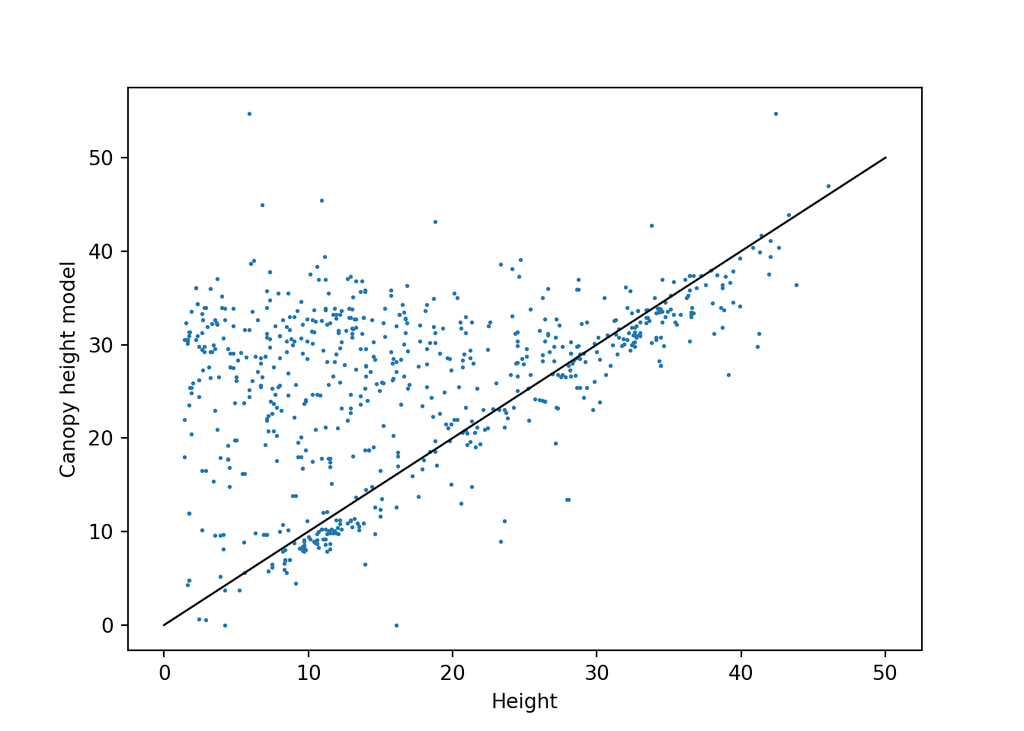

```python
valCHM = list(sample.sample_gen(chm,
                                tuple(zip(vegsub["adjEasting"],
                                          vegsub["adjNorthing"])),
                                masked=True))

fig, ax = plt.subplots()

ax.plot((0,50), (0,50), linewidth=1, color="black")
ax.scatter(vegsub.height, valCHM, s=1)

ax.set_xlabel("Height")
ax.set_ylabel("Canopy height model")

plt.show()
```

How strong is the correlation between the ground and lidar measurements?

```python
CHMlist = np.array([c.tolist()[0] for c in valCHM])
idx = np.intersect1d(np.where(np.isfinite(vegsub.height)),
                     np.where(CHMlist != None))
np.corrcoef(vegsub.height[idx], list(CHMlist[idx]))[0,1]
```

```
## np.float64(0.3913279146475449)
```

### Canopy height within a buffer of mapped tree locations

Now we remember there is uncertainty in the location of each tree, so the precise pixel it corresponds to might not be the right one. Let’s try adding a buffer to the extraction function, to get the tallest tree within the uncertainty of the location of each tree.

#### R

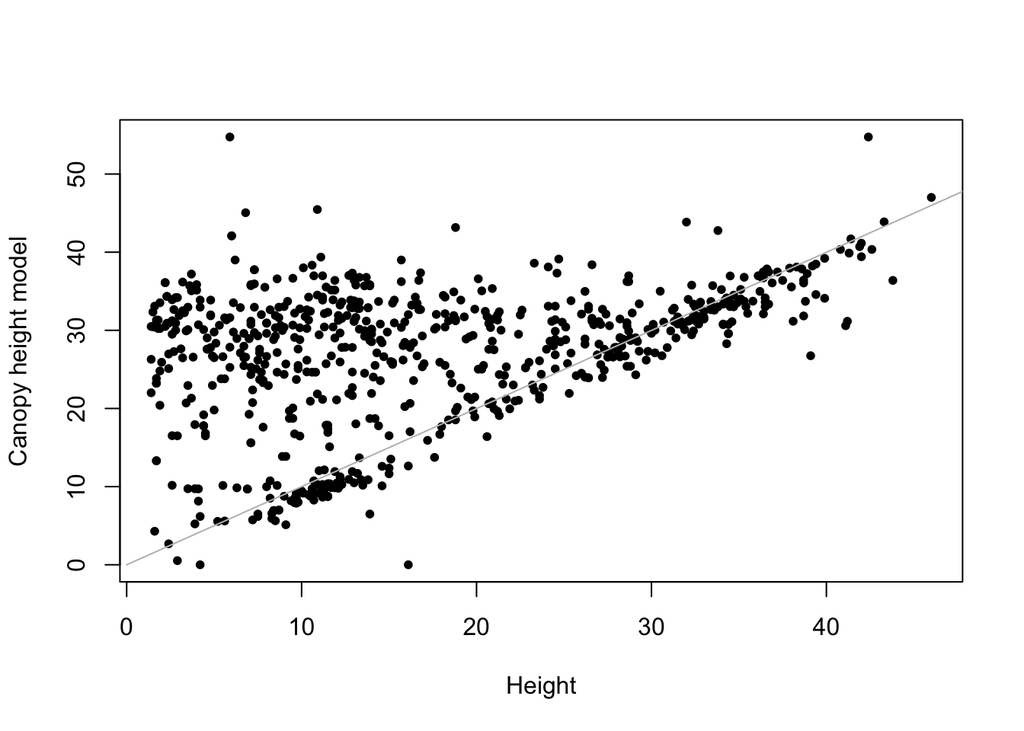

```r
valCHMbuff <- extract(chm,
                  buffer(vect(cbind(vegsub$adjEasting,
                  vegsub$adjNorthing)),
                  width=vegsub$adjCoordinateUncertainty),
                  fun=max)

plot(valCHMbuff$NEON_D16_WREF_DP3_580000_5075000_CHM~
       vegsub$height, pch=20, xlab="Height",
     ylab="Canopy height model")
lines(c(0,50), c(0,50), col="grey")
```

```r
cor(valCHMbuff$NEON_D16_WREF_DP3_580000_5075000_CHM,
    vegsub$height, use="complete")
```

```
## [1] 0.3846956
```

#### Python

To extract values using a buffer in Python, we need to create a shapefile of the buffered locations, and then extract the maximum value for each area in the shapefile.

```python
vegloc = vegsub[["individualID","adjEasting","adjNorthing","adjCoordinateUncertainty"]]
v = vegloc.rename(columns={"individualID": "indID", "adjEasting": "easting",
               "adjNorthing": "northing", "adjCoordinateUncertainty": "coordUnc"},
               inplace=False)

gdf = gpd.GeoDataFrame(
       v, geometry=gpd.points_from_xy(v.easting, v.northing))
gdf["geometry"] = gdf["geometry"].buffer(distance=gdf["coordUnc"])
gdf.to_file(os.getcwd() + "/trees_with_buffer.shp")
chm_height = rs.zonal_stats(os.getcwd() + "/trees_with_buffer.shp", chmx.values,
                            affine=chmx.rio.transform(),
                            nodata=-9999, stats="max")

valCHMbuff = [h["max"] for h in chm_height]
```

And plot the results:

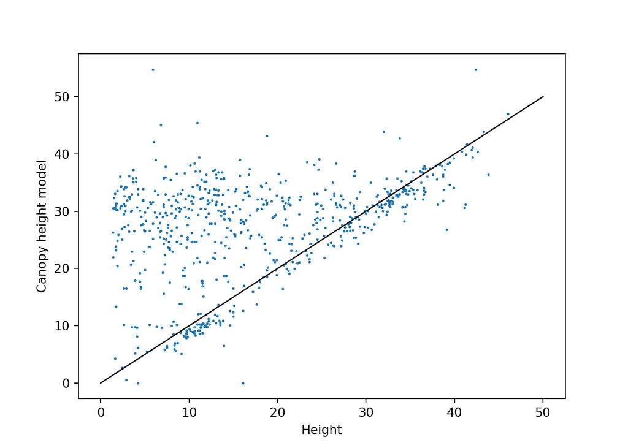

```python
fig, ax = plt.subplots()

ax.plot((0,50), (0,50), linewidth=1, color="black")
ax.scatter(vegsub.height, valCHMbuff, s=1)

ax.set_xlabel("Height")
ax.set_ylabel("Canopy height model")

plt.show()
```

```python
CHMbufflist = np.array(valCHMbuff)
idx = np.intersect1d(np.where(np.isfinite(vegsub.height)),
                     np.where(CHMbufflist != None))
np.corrcoef(vegsub.height[idx], list(CHMbufflist[idx]))[0,1]
```

```
## np.float64(0.3848610594340662)
```

Adding the buffer has actually made our correlation slightly weaker. Let’s think about the data.

There are a lot of points clustered on the 1-1 line, but there is also a cloud of points above the line, where the measured height is lower than the canopy height model at the same coordinates. This makes sense, because the tree height data include the understory. There are many plants measured in the vegetation structure data that are not at the top of the canopy, and the CHM sees only the top surface of the canopy.

This also explains why the buffer didn’t improve things. Finding the highest CHM value within the uncertainty of a tree should improve the fit for the tallest trees, but it’s likely to make the fit worse for the understory trees.

How to exclude understory plants from this analysis? Again, there are many possible approaches. We’ll try out two, one map-centric and one tree-centric.

### Compare maximum height within 10 meter pixels

Starting with the map-centric approach: select a pixel size, and aggregate both the vegetation structure data and the CHM data to find the tallest point in each pixel. Let’s try this with 10m pixels.

Start by rounding the coordinates of the vegetation structure data, to create 10m bins. Use `floor()` instead of `round()` so each tree ends up in the pixel with the same numbering as the raster pixels (the rasters/pixels are numbered by their southwest corners).

#### R

```r
easting10 <- 10*floor(vegsub$adjEasting/10)
northing10 <- 10*floor(vegsub$adjNorthing/10)
vegsub <- cbind(vegsub, easting10, northing10)
```

Use the `aggregate()` function to get the tallest tree in each 10m bin.

```r
vegbin <- stats::aggregate(vegsub,
                           by=list(vegsub$easting10,
                                   vegsub$northing10),
                           FUN=max)
```

To get the CHM values for the 10m bins, use the `terra` package version of the `aggregate()` function. Let’s take a look at the lower-resolution image we get as a result.

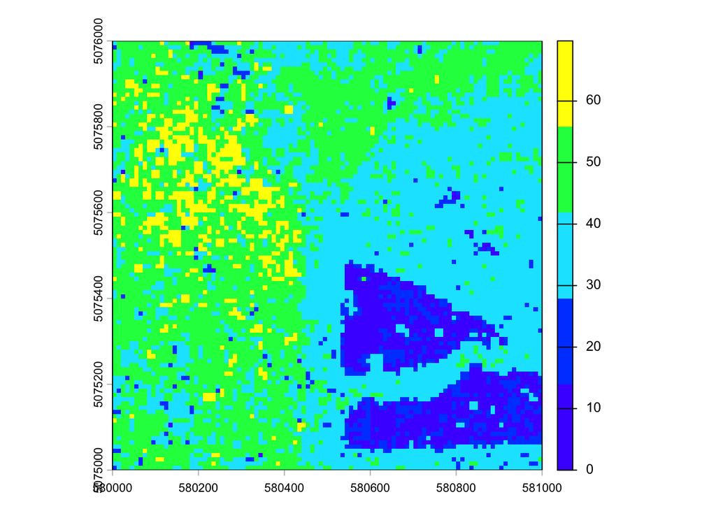

```r
CHM10 <- terra::aggregate(chm, fact=10, fun=max)
plot(CHM10, col=topo.colors(5))
```

Use the `extract()` function again to get the values from each pixel. Our grids are numbered by the corners, so add 5 to each tree coordinate to make sure it’s in the correct pixel.

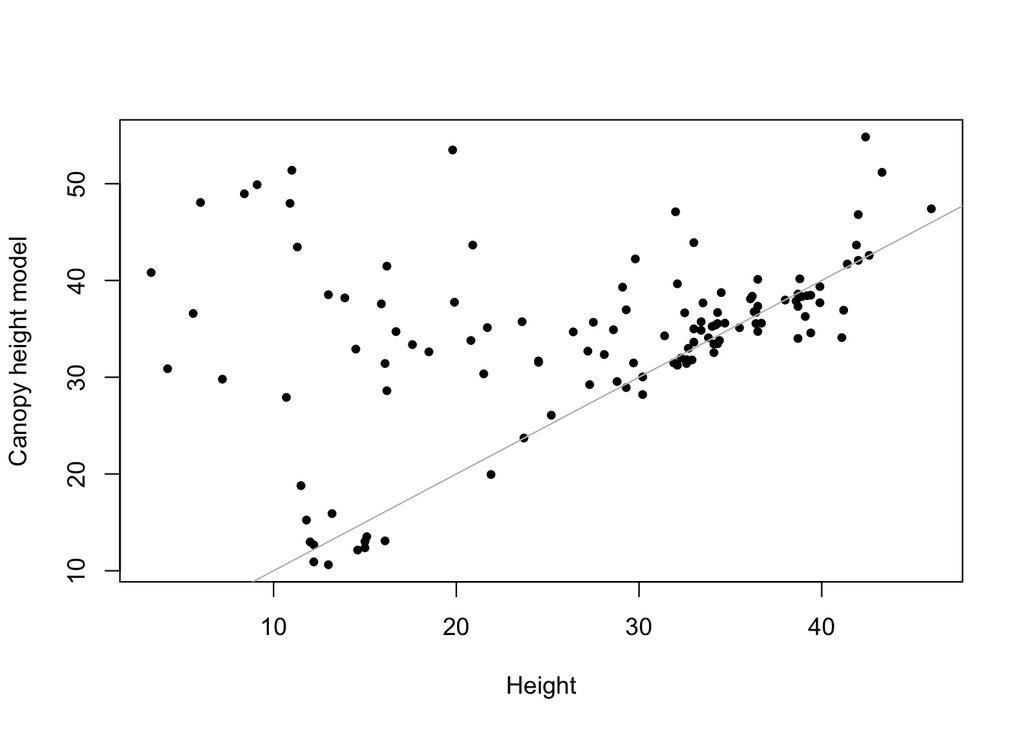

```r
vegbin$easting10 <- vegbin$easting10 + 5
vegbin$northing10 <- vegbin$northing10 + 5
binCHM <- extract(CHM10, cbind(vegbin$easting10,
                               vegbin$northing10))
plot(binCHM$NEON_D16_WREF_DP3_580000_5075000_CHM~
       vegbin$height, pch=20,
     xlab="Height", ylab="Canopy height model")
lines(c(0,50), c(0,50), col="grey")
```

```r
cor(binCHM$NEON_D16_WREF_DP3_580000_5075000_CHM,
    vegbin$height, use="complete")
```

```
## [1] 0.3593519
```

#### Python

```python
vegsub["easting10"] = 10*np.floor(vegsub.adjEasting/10)
vegsub["northing10"] = 10*np.floor(vegsub.adjNorthing/10)
vegsubloc = vegsub[["height","easting10","northing10"]]
```

Use the `groupby()` function to get the tallest tree in each 10m bin.

```python
vegbin = vegsubloc.groupby(["easting10", "northing10"]).max().add_suffix('_max').reset_index()
```

To get the CHM values for the 10m bins, use the `warp.reproject()` method in the `rasterio` package.

```python
target_res = (10, 10)

with rasterio.open(os.getcwd() + "/DP3.30015.001/neon-aop-products/2017/FullSite/D16/2017_WREF_1/L3/DiscreteLidar/CanopyHeightModelGtif/NEON_D16_WREF_DP3_580000_5075000_CHM.tif") as src:
     data, transform = rasterio.warp.reproject(source=src.read(),
                                src_transform=src.transform,
                                src_crs=src.crs,
                                dst_crs=src.crs,
                                dst_nodata=src.nodata,
                                dst_resolution=target_res,
                                resampling=Resampling.max)
     profile = src.profile
     profile.update(transform=transform, driver='GTiff',
                    height=data.shape[1], width=data.shape[2])

     with rasterio.open(os.getcwd() + '/CHM_10m.tif', 'w', **profile) as dst:
                    dst.write(data)

chm10 = rasterio.open(os.getcwd() + '/CHM_10m.tif')
```

Let’s take a look at the lower-resolution image we get as a result.

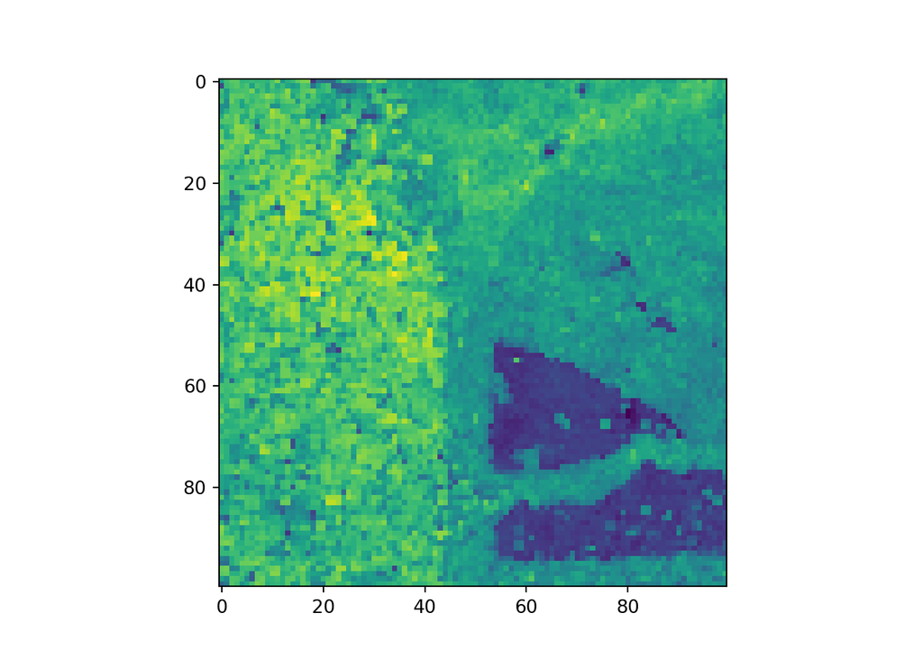

```python
plt.imshow(chm10.read(1))
plt.show()
```

Use the `sample()` function again to get the values from the pixel corresponding to each maximum tree height estimate. Our grids are numbered by the corners, so add 5 to each tree coordinate to make sure it’s in the correct pixel.

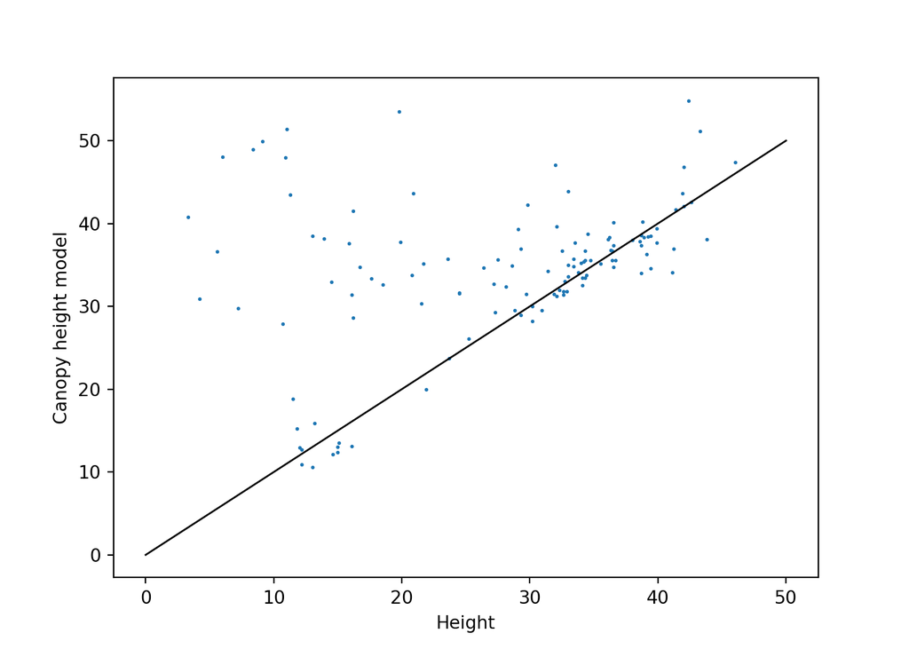

```python
valCHM10 = list(sample.sample_gen(chm10, tuple(zip(vegbin["easting10"]+5,
                                                   vegbin["northing10"]+5)),
                                                   masked=True))

fig, ax = plt.subplots()

ax.plot((0,50), (0,50), linewidth=1, color="black")
ax.scatter(vegbin.height_max, valCHM10, s=1)

ax.set_xlabel("Height")
ax.set_ylabel("Canopy height model")

plt.show()
```

```python
CHM10list = np.array([c.tolist()[0] for c in valCHM10])
idx = np.intersect1d(np.where(np.isfinite(vegbin.height_max)),
                     np.where(CHM10list != None))
np.corrcoef(vegbin.height_max[idx], list(CHM10list[idx]))[0,1]
```

```
## np.float64(0.35904092842414137)
```

The understory points are thinned out substantially, but so are the rest, and we’ve lost a lot of the shorter points. We’ve lost a lot of data overall by going to a lower resolution.

Let’s try and see if we can identify the tallest trees by another approach, using the trees as the starting point instead of map area.

### Find the top-of-canopy trees and compare to model

Start by sorting the veg structure data by height.

#### R

```r
vegsub <- vegsub[order(vegsub$height,
                       decreasing=T),]
```

Now, for each tree, let’s estimate which nearby trees might be beneath its canopy, and discard those points. To do this:

1. Calculate the distance of each tree from the target tree.
2. Pick a reasonable estimate for canopy size, and discard shorter trees within that radius. The radius I used is 0.3 times the height, based on some rudimentary googling about Douglas fir allometry. It could definitely be improved on!
3. Iterate over all trees.

We’ll use a simple `for` loop to do this:

```r
vegfil <- vegsub
for(i in 1:nrow(vegsub)) {
    if(is.na(vegfil$height[i]))
        next
    dist <- sqrt((vegsub$adjEasting[i]-vegsub$adjEasting)^2 +
                (vegsub$adjNorthing[i]-vegsub$adjNorthing)^2)
    vegfil$height[which(dist<0.3*vegsub$height[i] &
                        vegsub$height<vegsub$height[i])] <- NA
}

vegfil <- vegfil[which(!is.na(vegfil$height)),]
```

Now extract the raster values, as above.

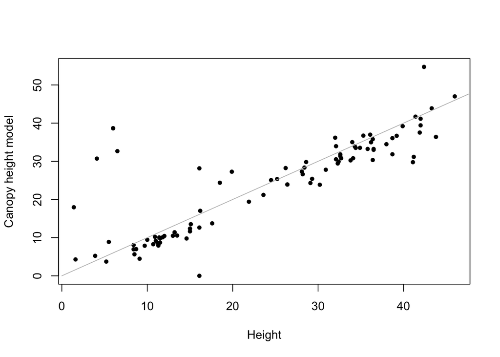

```r
filterCHM <- extract(chm,
                     cbind(vegfil$adjEasting,
                           vegfil$adjNorthing))
plot(filterCHM$NEON_D16_WREF_DP3_580000_5075000_CHM~
       vegfil$height, pch=20,
     xlab="Height", ylab="Canopy height model")
lines(c(0,50), c(0,50), col="grey")
```

```r
cor(filterCHM$NEON_D16_WREF_DP3_580000_5075000_CHM,
    vegfil$height)
```

```
## [1] 0.8170048
```

#### Python

```python
vegfil = vegsub.sort_values(by="height", ascending=False, ignore_index=True)
```

Now, for each tree, let’s estimate which nearby trees might be beneath its canopy, and discard those points. To do this:

1. Calculate the distance of each tree from the target tree.
2. Pick a reasonable estimate for canopy size, and discard shorter trees within that radius. The radius I used is 0.3 times the height, based on some rudimentary googling about Douglas fir allometry. It could definitely be improved on!
3. Iterate over all trees.

We’ll use a simple `for` loop to do this:

```python
height = vegfil.height.reset_index()
for i in vegfil.index:
    if height.height[i] is None:
        pass
    else:
        dist = np.sqrt(np.square(vegfil.adjEasting[i]-vegfil.adjEasting) +
                       np.square(vegfil.adjNorthing[i]-vegfil.adjNorthing))
        idx = vegfil.index[(vegfil.height<height.height[i]) & (dist<0.3*height.height[i])]
        height.loc[idx, "height"] = None
```

Now extract the raster values, as above.

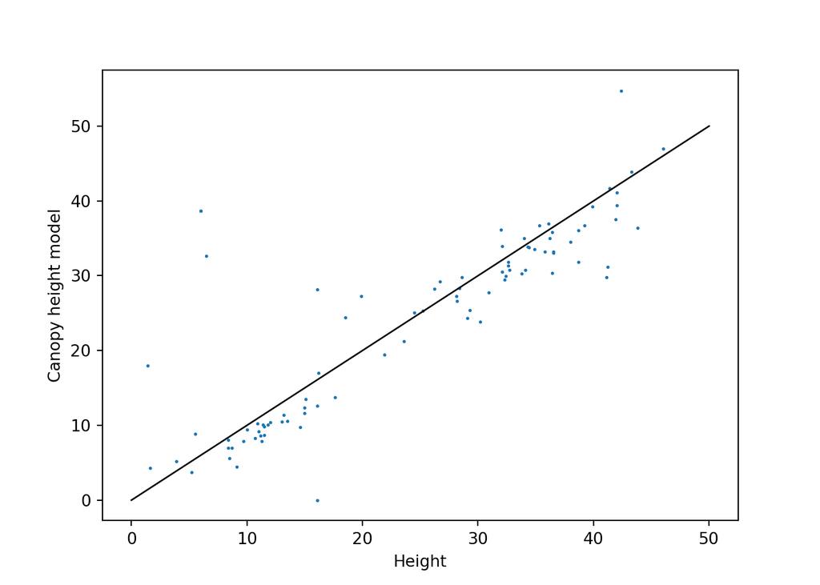

```python
filterCHM = list(sample.sample_gen(chm, tuple(zip(vegfil["adjEasting"],
                                                  vegfil["adjNorthing"])),
                                                  masked=True))

fig, ax = plt.subplots()

ax.plot((0,50), (0,50), linewidth=1, color="black")
ax.scatter(height.height, filterCHM, s=1)

ax.set_xlabel("Height")
ax.set_ylabel("Canopy height model")

plt.show()
```

```python
filCHMlist = np.array([c.tolist()[0] for c in filterCHM])
idx = np.intersect1d(np.where(np.isfinite(height.height)),
                     np.where(filCHMlist != None))
np.corrcoef(height.height[idx], list(filCHMlist[idx]))[0,1]
```

```
## np.float64(0.8393670222898226)
```

This is quite a bit better! There are still several understory points we failed to exclude, but we were able to filter out most of the understory without losing so many overstory points.

### Remove dead trees

Let’s try one more thing. The `plantStatus` field in the veg structure data indicates whether a plant is dead, broken, or otherwise damaged. In theory, a dead or broken tree can still be the tallest thing around, but it’s less likely, and it’s also less likely to get a good Lidar return. Exclude all trees that aren’t alive:

#### R

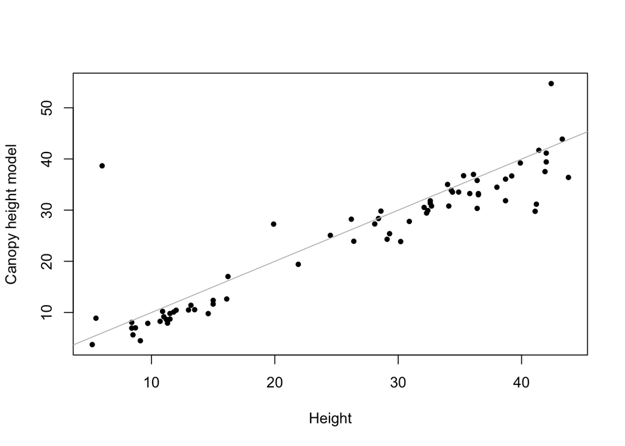

```r
vegfil <- vegfil[which(vegfil$plantStatus=="Live"),]

filterCHM <- extract(chm,
                     cbind(vegfil$adjEasting,
                           vegfil$adjNorthing))

plot(filterCHM$NEON_D16_WREF_DP3_580000_5075000_CHM~
       vegfil$height, pch=20,
     xlab="Height", ylab="Canopy height model")

lines(c(0,50), c(0,50), col="grey")
```

```r
cor(filterCHM$NEON_D16_WREF_DP3_580000_5075000_CHM,
    vegfil$height)
```

```
## [1] 0.9113093
```

#### Python

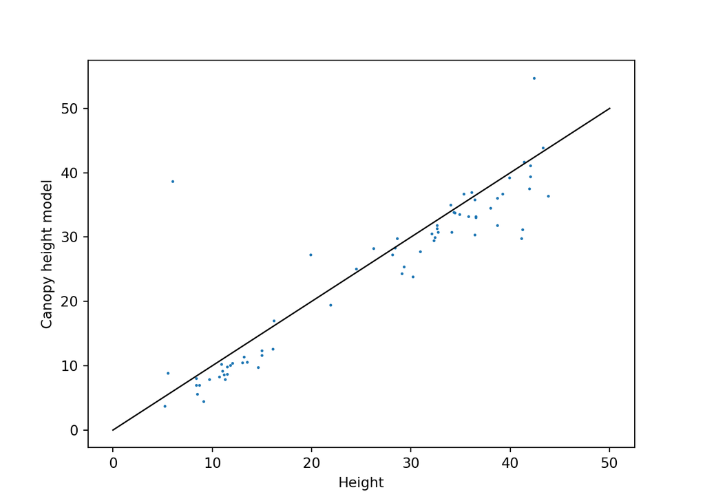

```python
idx = vegfil.index[vegfil.plantStatus!="Live"]
height.loc[idx, "height"] = None

fig, ax = plt.subplots()

ax.plot((0,50), (0,50), linewidth=1, color="black")
ax.scatter(height.height, filterCHM, s=1)

ax.set_xlabel("Height")
ax.set_ylabel("Canopy height model")

plt.show()
```

```python
idx = np.intersect1d(np.where(np.isfinite(height.height)),
                     np.where(filCHMlist != None))
np.corrcoef(height.height[idx], list(filCHMlist[idx]))[0,1]
```

```
## np.float64(0.9113648148226839)
```

Nice!

### Final thoughts on intercomparison

This tutorial has explored different ways of relating remotely sensed to ground-based data. Although some of the options we tried resulted in stronger correlations than others, the approach you choose will probably depend most on the research questions you are trying to answer. The goal of this tutorial has been to help you think through the possibilities, and identify some of the pitfalls and biases.

Speaking of biases: however we slice the data, there is a noticeable bias even in the strongly correlated values. The CHM heights are generally a bit shorter than the ground-based estimates of tree height. There are two biases in the CHM data that contribute to this. (1) Lidar returns from short-stature vegetation are difficult to distinguish from returns from the ground itself, so the “ground” estimated by Lidar is often a bit higher than the true ground surface, and (2) the height estimate from Lidar represents the highest return, but the highest return may slightly miss the actual tallest point on a given tree. This is especially likely to happen with conifers, which are the top-of-canopy trees at Wind River.

Finally, as you explore other types of both remote sensing and ground data, keep in mind that the two datasets we examined here, tree height and canopy height model, are an unusual pair in that both are measuring the same quantity in the same units. Attempting to relate remote sensing and ground data can be much more complicated in other scenarios, such as the relationships between leaf chemistry and reflectance indices.